# Light Runner, an exercise in digital preservation

In my teens, I wrote a Tron work-alike called *Light Runner* in assembly for the Color Computer; I even got Prickly Pear Software to release it commercially. I can't find my source code (*Grrr!*), but I have a copy of the product on cassette tape. I didn't quite get it restored to working order, but I had some fun trying.

[figure not shown]

Light Runner and The Facts for the CoCo

The analog-to-digital-signal bit was only complicated by the fact that the cassette player couldn't be connected to my desktop:

1. put the cassette in the boombox
2. hook the boombox to the netbook
3. use "Sound Recorder" to make `lr.wma`
4. move `lr.wma` to my desktop via a thumb drive
5. use Audacity to chop off the dead air and save in `.wav` format

[figure not shown]

Audio cassette data in Audacity

**Processing the digital signal** involved a steep learning curve. As explained on pg. 10 of The FACTS:

> G. Cassette Interface - Cassette data is stored onto the tape using a format called Frequency Shift Keying (FSK). This means that two sine waves of differing frequency are used to zeroes and ones on the tape. A sine wave of 2400 hz is used to store a one, and a sine wave of 1200 Hertz is used to store a zero.

I surfed around, wondering whether to make this an R project or a numpy project. The clincher was a StackOverflow clue on [detecting zero crossings](http://stackoverflow.com/a/3843124) by Jim Brissom Oct 1 2010:

```python
%pylab inline
```

```
Welcome to pylab, a matplotlib-based Python environment [backend: module://IPython.zmq.pylab.backend_inline].
For more information, type 'help(pylab)'.
```

```python
def zero_crossings(signal):
    return numpy.where(numpy.diff(numpy.sign(signal)))[0]
a = [1, 2, 1, 1, -3, -4, 7, 8, 9, 10, -2, 1, -3, 5, 6, 7, -10]
zero_crossings(a)
```

```
array([ 3,  5,  9, 10, 11, 12, 15])
```

Making a numpy array out of a `.wav` file is a piece of cake. Scaling the amplitude to fit in an 8 bit DAC like the CoCo's helps eliminate some high frequency noise: (@@see `cloadm.py`)

```python
import wave
import cloadm as c
tape_fn = 'lr-cut.wav'
dest_fn = 'light-runner'
tape = wave.open(tape_fn, 'r')
dest = open(dest_fn, 'w')
framerate, signal = c.wavLoadMono(tape)
amp_max = 128  # 8 bit signed
signal = signal * amp_max / max(signal)
framerate, len(signal), signal[:5]
```

```
(44100, 1223945, array([16, 17, 17, 17, 17]))
```

The next step is to find the long sequence of alternating 0s and 1s that mark the beginning of a sequence of bytes. In Audacity, I could hear the tone right around 2 seconds in. The signal at this point looks about right:

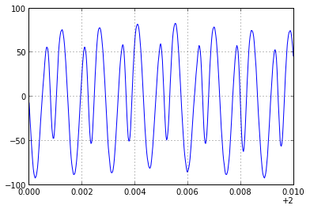

```python
t = arange(2.0, 2.01, 1.0/framerate)
_ = plot(t,
         signal[t[0] * framerate:t[0] * framerate + len(t)])
grid()
```

The pattern of bits was close, but not quite there, no matter how I played with the threshold:

```python
freqs, wave_ix = c.waves(zero_crossings(signal), framerate)
threshold = 1400  # experimental; cf. (CoCo.rate0 + CoCo.rate1) / 2
bits = (freqs > threshold) + 0
bits[wave_ix > 2.0 * framerate][:40]
```

```
array([1, 0, 1, 0, 1, 0, 1, 1, 1, 0, 1, 0, 1, 0, 1, 0, 1, 0, 1, 1, 0, 1, 0,
       1, 0, 1, 0, 1, 1, 1, 0, 1, 0, 1, 0, 1, 0, 1, 1, 0])
```

I pored over the disassembly from *The FACTS*, wondering what I'd missed:

*** LOOK FOR THE SYNC BYTES - RETURN WITH ACCA = 0 IF SYNC’ED *** ON HI - LO TRANSITION, ACCA = $A0 IF SYNC’ED ON THE *** LO - HI TRANSITION OF THE INPUT SIGNAL FROM THE CASSETTE. CASON ORCC #$50 DISABLE IRQ,FIRQ BSR LA7CA TURN ON TAPE DECK MOTOR CLR CPULWD RESET UP TO SPEED COUNTER LA782 BSR LA763 WAIT FOR LO-HI TRANSITION LA784 BSR LA7AD WAIT FOR HI-LO TRANSITION BHI LA797 CASSETTE SPEED IN RANGE FOR 1200 HZ LA788 BSR LA7A7 WAIT FOR LO-HI TRANSITION BCS LA79B CASSETTE SPEED IN RANGE FOR 2400 HZ DEC CPULWD DECREMENT UP TO SPEED COUNTER IF SYNC’ED ON LO-HI LDA CPULWD GET IT CMPA #-96 HAVE THERE BEEN 96 CONSECUTIVE 1-0-1-0 PATTERNS LA792 BNE LA782 NO STA CBTPHA SAVE WHICH TRANSITION (HI-LO OR LO-HI) RTS

*Aside*: I haven't found *The FACTS* online, but the disassemblies are also available in [Color-Basic-Unravelled.pdf](https://sites.google.com/a/aaronwolfe.com/cococoding/home/docs/color-basic-unravelled.pdf?attredirects=0&d=1), also by Spectral Associates, digitally restored by [Aaron Wolfe](https://sites.google.com/a/aaronwolfe.com/).

I finally found the bug by

- focussing on an even smaller section of the signal,
- together with the calculated frequencies and the derived bits:

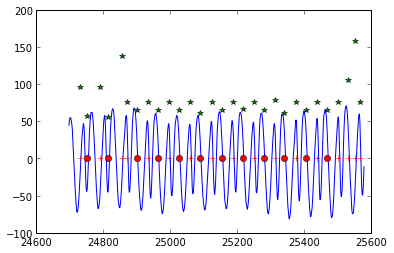

```python
lo = int(framerate * 0.560)
hi = int(framerate * 0.580)
lo, hi

ix = intersect1d(where(wave_ix > lo)[0], where(wave_ix < hi)[0])

ones = ix[bits[ix] == 1]
zeros = ix[bits[ix] == 0]
_ = plot(arange(lo, hi), signal[lo:hi], 'b-',
         wave_ix[ix], (freqs/20)[ix], 'g*',
         wave_ix[ones], bits[ones], 'r+',
         wave_ix[zeros], bits[zeros], 'ro')
```

Do you see it?

The crossings start lo-hi for the first five bits, but somehow the next bit is marked at a hi-lo transition.

I added a line of code to say that they should all go the same direction:

```
    assert((numpy.sign(signal[z[::2]]) == numpy.sign(z[0])).all())
```

When the signal crossed zero by actually hitting zero, it threw things off. So I tweaked `zero_crossings` algorithm to use `sign() > 0` so that we have just +/-, rather than +1/0/-1:

```python
def zero_crossings(signal):
    return numpy.where(numpy.diff(numpy.sign(signal) > 0))[0]

zero_crossings([2, 1, 0, -1, -2, 1, 4, -4])
```

```
array([1, 4, 6])
```

Now the 1's and 0's alternate nicely:

```python
freqs, wave_ix = c.waves(zero_crossings(signal), framerate)
threshold = 1400  # experimental; cf. (CoCo.rate0 + CoCo.rate1) / 2
bits = (freqs > threshold) + 0
bits[wave_ix > 2.0 * framerate][:40]
```

```
array([1, 0, 1, 0, 1, 0, 1, 0, 1, 0, 1, 0, 1, 0, 1, 0, 1, 0, 1, 0, 1, 0, 1,
       0, 1, 0, 1, 0, 1, 0, 1, 0, 1, 0, 1, 0, 1, 0, 1, 0])
```

This allows us to find the sync pattern:

```python
c.find_sync(bits)
```

```
1145
```

Putting it all together, we see that we get a certain distance before falling out of sync:

```python
import logging
logging.basicConfig(level=logging.INFO)
import StringIO
tape = wave.open(tape_fn, 'r')
dest = StringIO.StringIO()
try:
    c.decode(tape, dest)
except ValueError:
    print "oops!"
```

```
INFO:cloadm:block type: 0 length: 15
INFO:cloadm:block type: 1 length: 255
WARNING:cloadm:expected check $88 does not match found $8
INFO:cloadm:block type: 1 length: 255
WARNING:cloadm:expected check $6d does not match found $ed
INFO:cloadm:block type: 1 length: 255
INFO:cloadm:block type: 1 length: 255
INFO:cloadm:block type: 1 length: 255
INFO:cloadm:block type: 1 length: 255
INFO:cloadm:block type: 1 length: 255
WARNING:cloadm:expected check $f0 does not match found $70
INFO:cloadm:block type: 1 length: 255
WARNING:cloadm:expected check $6 does not match found $86
WARNING:cloadm:expected block start $55 does not match found $ab
WARNING:cloadm:expected block start $3c does not match found $78
INFO:cloadm:block type: 2 length: 254
```

```
oops!
```

The filename and copyright statement confirm that we're on the right track:

```python
content = dest.getvalue()
print "filename:", content[:8]
print
print content[229:298].replace('\x00', '\n')
```

```
filename: RUNNER

LIGHT RUNNER
COPR(C) 1983 BY CO&CO SOFTWARE
WRITTEN BY: DAN CONNOLLY
```

## Related Work

Browsing around the [coco mailing list](http://five.pairlist.net/pipermail/coco/) I found a `CASIN.EXE` program by Jeff Vavasour circa 1994; I got it running under dosbox; the first thing it said was:

```
This .WAV file is not a 11025Hz/mono/8-bit sample.
```

So sox to the rescue:

```
$ `sox ../../lr-cut.wav -r 11025 -b 8 lr8.wav`
```

Then `CASIN` made some progress, but didn't get very far. It decoded even less data than my code did. I might have felt a little silly poring over all the low-level details if there was a well-known solution that worked out of the box. But data analysis and signal processing is a growing part of my day job, and learning the scientific python toolset has been on my todo list for quite some time, so I'm glad I did.

## Colophon

I'm trying out [IPython](http://ipython.org/) as an authoring tool. I'm fond of the interactive notebook idea. The 0.12 version that comes with Ubuntu didn't support inline plotting, and cell selection was glitchy. But I'm using 0.14dev, and while it doesn't quite feel as mature as RStudio, it's getting pretty close.